# Introduction to infectious disease modelling tutorial: Hawkes Process models

StanCon 2024

Ettie Unwin

2024-02-23

This tutorial is loosely based on the idea [here](https://journals.plos.org/ploscompbiol/article?id=10.1371/journal.pcbi.1008830) to using Hawkes Processes to model infectious diseases. This work is licensed under a [Creative Commons Attribution-NonCommercial-NoDerivatives 4.0 International License](https://creativecommons.org/licenses/by-nc-nd/4.0/).

[Hawkes Processes](https://arxiv.org/abs/1708.06401) are mathematically well founded statistical point process, where the intensity $\lambda$

$$\begin{equation}
\lambda = \mu + \sum_{t>t_i} \phi(t-t_i).
\end{equation}$$

Here $\mu$ is a contribution to the intensity from the background - in the case of infectious diseases this could be cases imported from a region outside your area of interest or spillover from an animal reservoir - and $\phi$ is the self exciting kernel that describes person to person infection. There are many options for how to parameterise $\mu$ and $\phi$ but for ease we will keep $\mu$ to be a fixed constant and $\phi$ to be an exponential kernel.This means there is a constant chance of an infection to be caused by the background and a person is most infectious at the point of infection (this assumption can be relaxed by using a [Rayleigh kernel](https://en.wikipedia.org/wiki/Rayleigh_distribution)).

One benefit of the Hawkes Process is that it is often possible to write down the likelihood analytically. If
$$\begin{equation}
\lambda = \mu + \sum_{t>t_i} \alpha e^{-\delta(t-t_i)},
\end{equation}$$

then our log-likelihood $\ell(\alpha, \delta, \mu)$

$$\begin{equation}
\ell(\alpha, \delta, \mu) = \frac{\alpha}{\delta}\sum_{i=1}^{n}(e^{-\delta(T-t_i)} - 1) - \mu T + \sum_{i=1}^{N}\log (\mu + \sum_{j=1}^{i-1}\alpha e^{t_i - t_j}).
\end{equation}$$

This type of model is useful if you have line list data. This means you have a line in your data for each patient including times that they developed symptoms, got a test and maybe some demographics like their age, sex and location.

You can code up your likelihood in the functions block of the stan model file. Here is an un-optimised implementation - I would be delighted with an optimised version if anyone is interested enough to create one!

```
functions {

  real log_likelihood(real mu, real alpha, real delta, vector events_list, int N, real max_T){

        // first term

        vector[N] differences_from_max_T = max_T - events_list;
        vector[N] summands = exp(-delta * differences_from_max_T) - 1;

        vector[N] within_max_T_Mask = non_negative_mask(differences_from_max_T);
        summands = summands .* within_max_T_Mask;

        real first = mu * max_T - (alpha / delta) * sum(summands);

        // second term

        matrix[N, N] differences_mat = self_differences(events_list);
        matrix[N, N] inner_sum_mat = exp(-delta * differences_mat);
        inner_sum_mat = zero_above_diagonal(inner_sum_mat);

        vector[N] term_inside_log = mu + alpha * rowsum(inner_sum_mat);

        vector[N] second_sum_terms = log(term_inside_log);

        real second = sum(second_sum_terms);

        return -first + second;
  }

    matrix zero_above_diagonal(matrix input_mat){
        int N = rows(input_mat);
        matrix[N, N] output_mat;

        for (i in 1:N) {
            for (j in 1:N) {
                if (j >= i) {
                   output_mat[i, j] = 0;
                } else {
                   output_mat[i, j] = input_mat[i, j];
                }
            }
        }

        return output_mat;
    }

    vector rowsum(matrix input_mat){
        int M = cols(input_mat);
        vector[M] v = rep_vector(1.0, M);

        return input_mat * v;
    }

    vector non_negative_mask(vector input_vec){
        int N = num_elements(input_vec);
        vector[N] output_vec;

        for (i in 1:N) {
            output_vec[i] = input_vec[i] > 0;
        }

        return output_vec;
    }

    matrix self_differences(vector input_vec){
        int N = num_elements(input_vec);

        row_vector[N] rv = input_vec';

        matrix[N, N] output_mat = rep_matrix(input_vec, N) - rep_matrix(rv, N);

        return output_mat;
    }


}
```

Then we also need to define the data block of the model file. Here we say we are fitting to a list of events times (event_list) with length N and maximum time max_T:

```r
data {
    int<lower=0> N;
    vector[N] events_list;
    real max_T;
}
```

We have three parameters in our model $\alpha$ which controls the magnitude of the infectious profile, $\delta$ which controls the duration of the infectious period and $\mu$ which controls the background infection rate:

```r
parameters {
    real mu;
    real <lower=0> alpha;
    real <lower=0> delta;
}
```

Finally we can define our model and choose priors. Here we have assumed that our parameters are normally distributed for ease, but these can be carefully considered.

```r
model {
    mu ~ normal(0.5 , 1 );
    alpha ~ normal(0.4 , 0.1 );
    delta ~ normal(0.5 , 1 );

    target += log_likelihood(mu, alpha, delta, events_list, N, max_T);
}
```

```r
library(rstan)
```

```r
library(bayesplot)
mc.cores = parallel::detectCores()
rstan_options(auto_write = TRUE)

# read in data
events = readRDS("data/hawkes.RDS")

# data for Stan
data <- list(N = length(events),
             events_list = events,
             max_T = max(events))

# number of MCMC steps
niter <- 5000

model <- stan_model("stan_models/exp_hawkes.stan")

fit <- sampling(model,
                data = data,
                iter = niter,
                chains = 4,
                seed = 0)
print(summary(fit))
```

```
## $summary
##                mean     se_mean         sd        2.5%         25%         50%
## mu        0.9853324 0.003905618 0.21686309   0.5280019   0.8440586   0.9999068
## alpha     0.3642528 0.001335100 0.08904108   0.1905476   0.3032174   0.3649823
## delta     1.2565788 0.009655140 0.57991295   0.4341776   0.8194091   1.1491051
## log_lik -89.2517830 0.011469143 0.80389133 -91.3810941 -89.5244101 -89.0198449
## lp__    -91.2822359 0.022154360 1.22210023 -94.5838943 -91.8123160 -90.9339081
##                 75%       97.5%    n_eff     Rhat
## mu        1.1409616   1.3674989 3083.129 1.000606
## alpha     0.4259684   0.5368584 4447.880 1.000414
## delta     1.6008816   2.6232526 3607.518 1.000997
## log_lik -88.7334846 -88.2933041 4912.842 1.000223
## lp__    -90.4014568 -89.9467100 3042.953 1.000989
##
## $c_summary
## , , chains = chain:1
##
##          stats
## parameter        mean         sd        2.5%         25%         50%
##   mu        0.9944019 0.20919370   0.5575897   0.8522001   1.0100498
##   alpha     0.3670462 0.09064809   0.1941936   0.3039649   0.3674415
##   delta     1.2752330 0.57047110   0.4586873   0.8376220   1.1758230
##   log_lik -89.2320746 0.80971066 -91.4610118 -89.4868106 -88.9972321
##   lp__    -91.2514880 1.18330680 -94.4811603 -91.7657974 -90.9202026
##          stats
## parameter         75%       97.5%
##   mu        1.1456246   1.3561808
##   alpha     0.4308683   0.5413903
##   delta     1.6189375   2.6240150
##   log_lik -88.7254289 -88.2879034
##   lp__    -90.3888909 -89.9436268
##
## , , chains = chain:2
##
##          stats
## parameter        mean         sd        2.5%         25%         50%
##   mu        0.9804818 0.21316362   0.5388818   0.8415265   0.9884096
##   alpha     0.3611096 0.08860604   0.1936314   0.3009887   0.3588981
##   delta     1.2271622 0.56896164   0.4303596   0.8008441   1.1126535
##   log_lik -89.2558382 0.79357905 -91.2539020 -89.5453577 -89.0333677
```

[output cut: 27 more lines]

```
##
##          stats
## parameter        mean         sd        2.5%         25%         50%
##   mu        0.9803946 0.21767237   0.5128000   0.8407138   0.9924286
##   alpha     0.3631487 0.08668492   0.1835907   0.3078094   0.3661032
##   delta     1.2437891 0.57237658   0.4323554   0.8129386   1.1462111
##   log_lik -89.2417896 0.78549416 -91.3383796 -89.4946219 -89.0177598
##   lp__    -91.2506506 1.22848256 -94.5493852 -91.7523924 -90.8676746
##          stats
## parameter         75%       97.5%
##   mu        1.1330519   1.3677637
##   alpha     0.4235105   0.5244889
##   delta     1.5759938   2.5756216
##   log_lik -88.7395982 -88.2964243
##   lp__    -90.3856895 -89.9454571
```

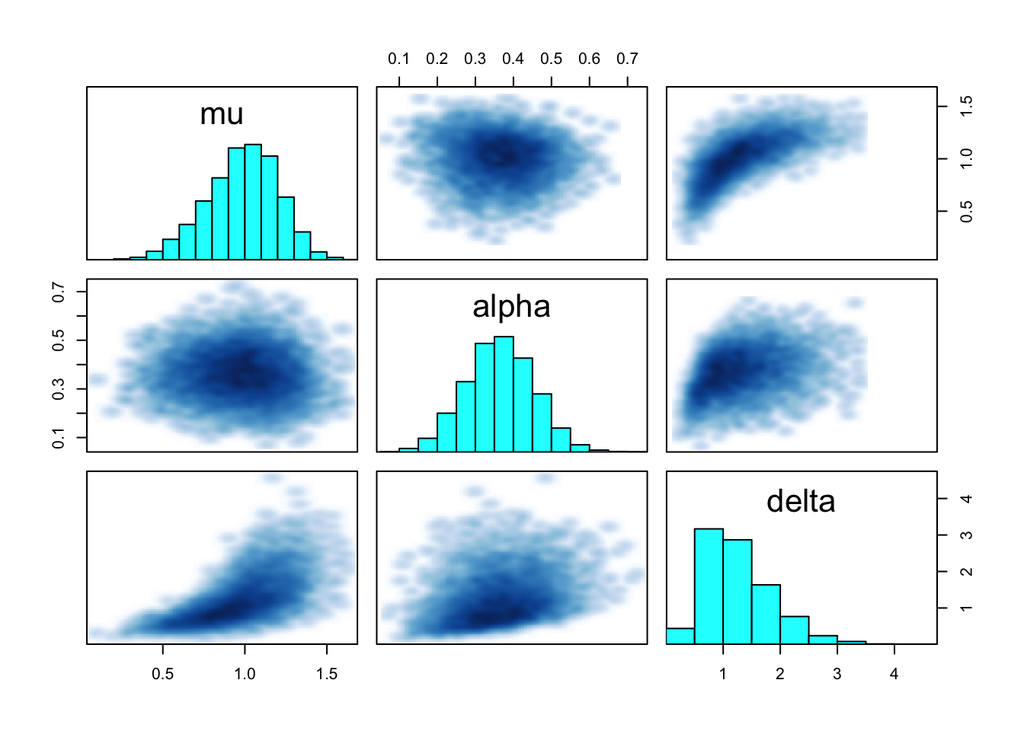

```r
pairs(fit, pars = c("mu", "alpha", "delta"))
```

We can see that despite this, our chains are mixing ok.

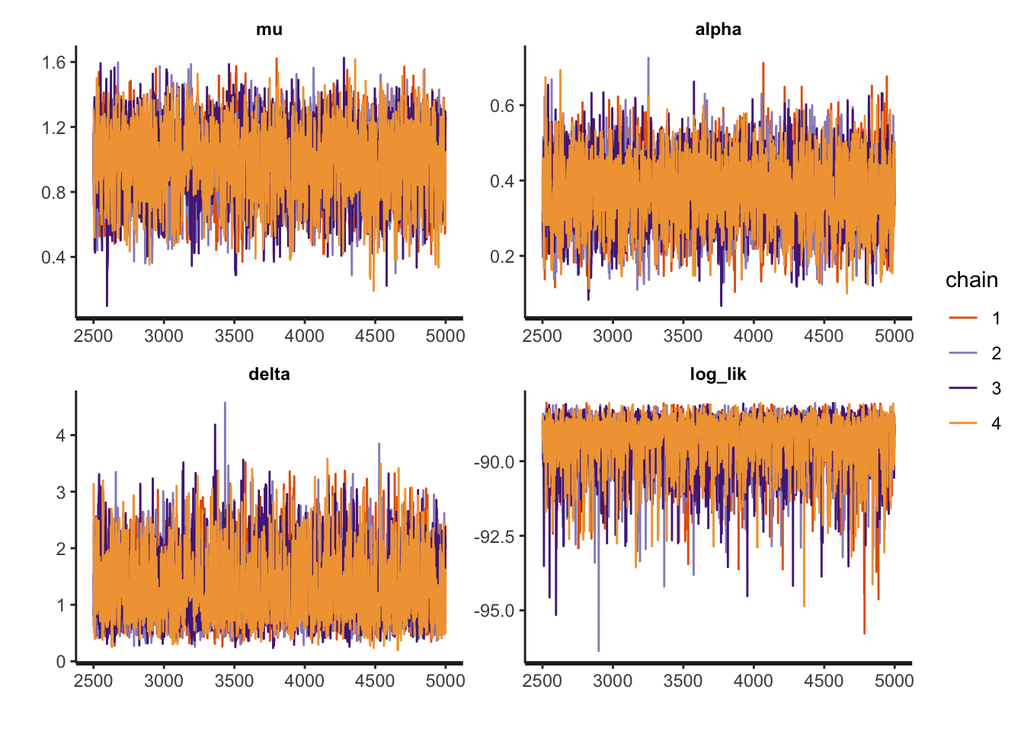

```r
traceplot(fit)
```

We can now explore the posterior distributions for our distribution which enable us to determine values for the parameters in our model.

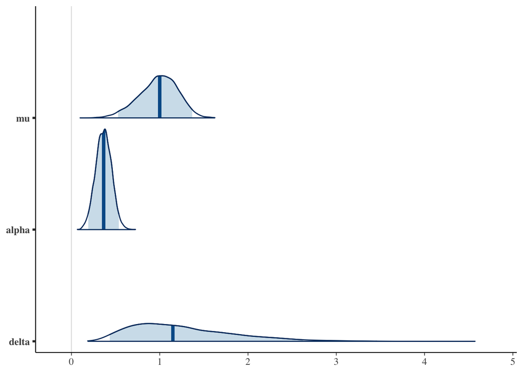

```r
posterior <- as.matrix(fit)
p <- mcmc_areas(posterior[,1:3],
                prob = 0.95)
print(p)
```